# Rhomework4: Stress Research

Ting Yin

## Introduction

### What is it?

This reseach is to analyse and compare the level of stress between different groups (for example: male and female, undergraduates and graduate students) in the University of Rochester. I want to know the distribution of stress among students, and whether the distribution varys across different groups.

### Why?

In UR, we can find some students very busy and stressful while others leisurely. This makes me wander whether this difference obeys certain laws. which kind people are facing more stress and which kind people facing less?

### How?

This research is collecting data via questionnaire made by Google Sheet. Several questions are asked to students (subjects) in order to obtain their basic information and evaluate their stress. For more detail on the questionnaire please see: https://goo.gl/forms/3V78TEdCjQ14XGQC3.

## Overview

I chose five classifications to do the research: **gender**, **education level**, **international students or not**, **schools and colleges**, and **learning goals**.

1. Gender:
   - Female
   - Male
2. Current education levels:
   - Undergraduates
   - Graduate students
3. International students & not
4. Schools and colleges:
   - Arts, Science and Engineering
   - Eastman School of Music
   - School of Medicine and Dentistry
   - School of Nursing
   - Eastman Institute for Oral Health
   - Simon Business School
   - Warner Graduate School of Education
5. Learning Goals:
   - Achievements in academic performance
   - Promotion in soft skills (e.g. Leadership, Social Skills)
   - Do not have specific goals

So far I have collected 33 samples.The following are basic statistics of these subjects (Due to the small volume of the sample set, the analyses to learning goals is not included in this report).

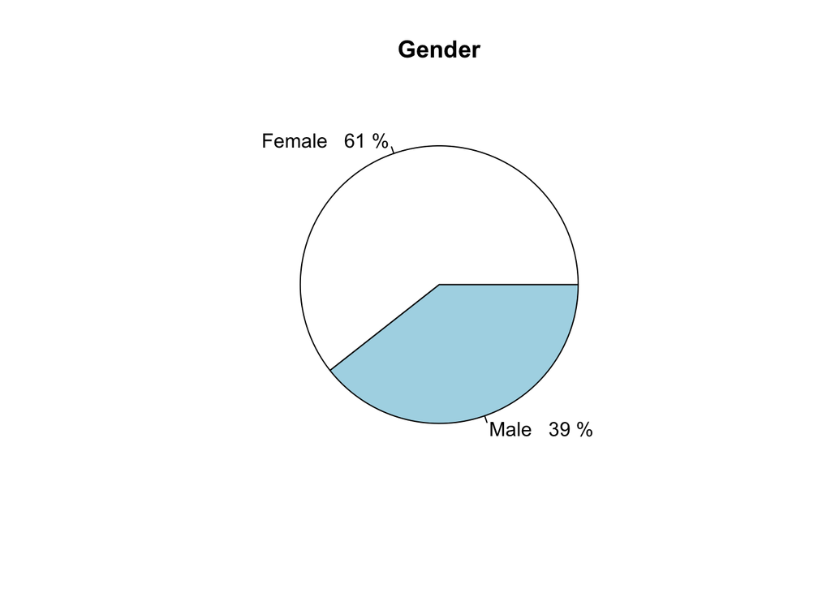

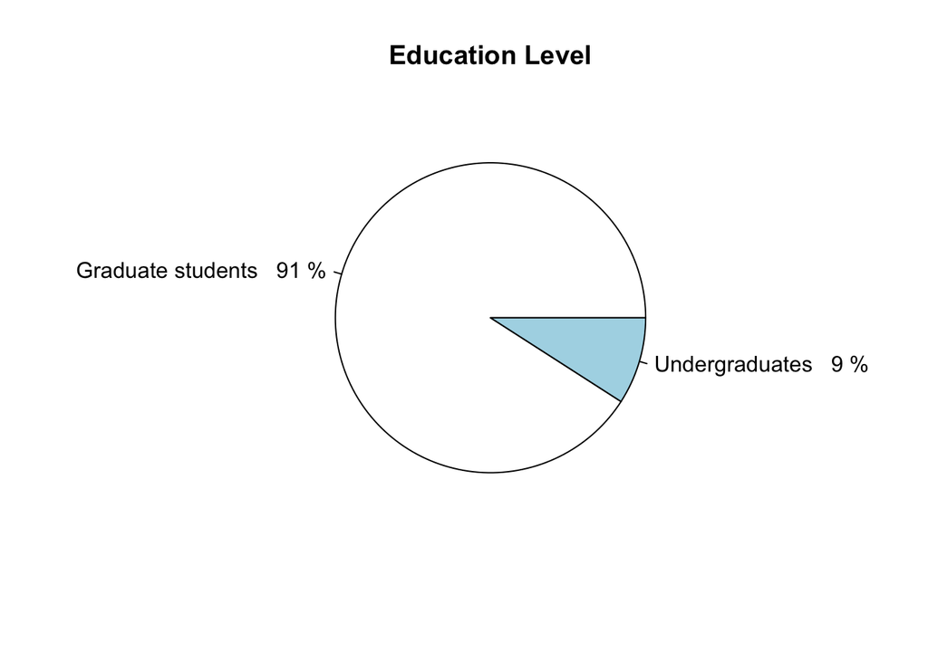

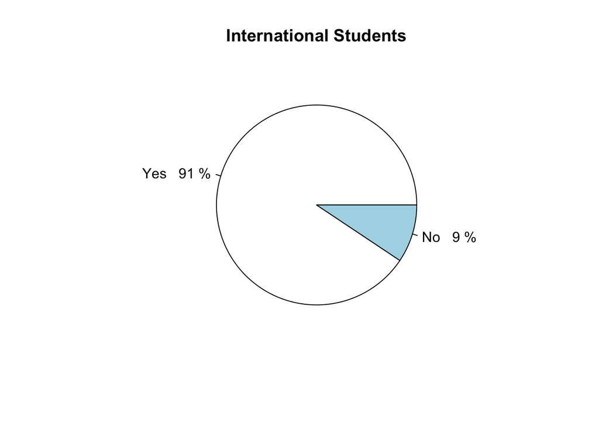

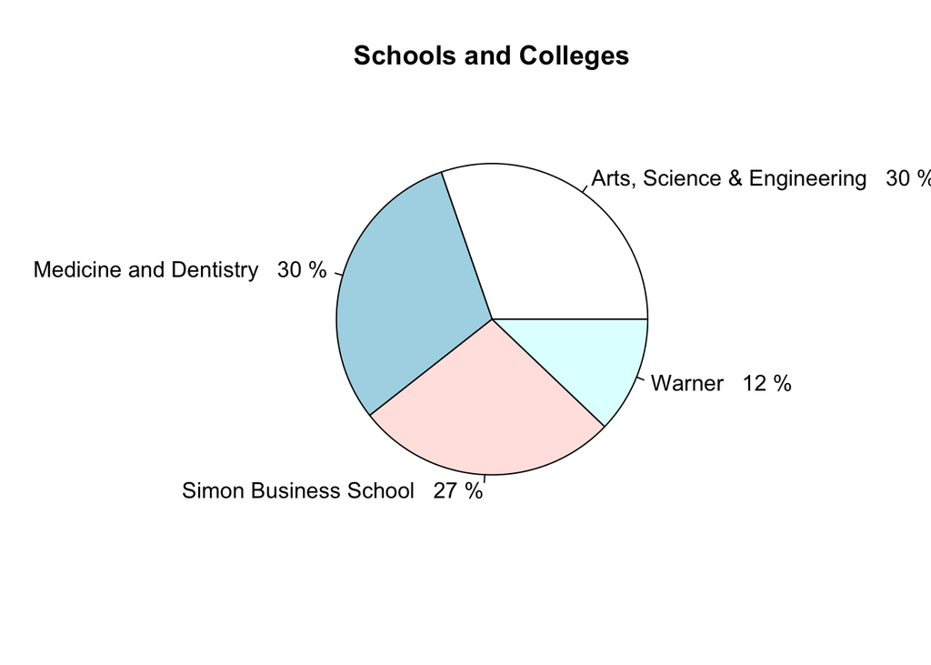

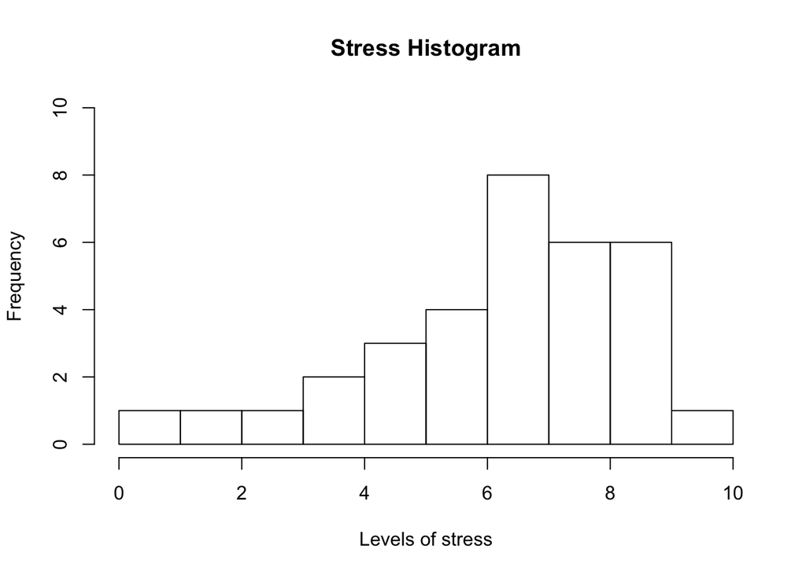

## Exploratory Analyses

#### Groups - Gender

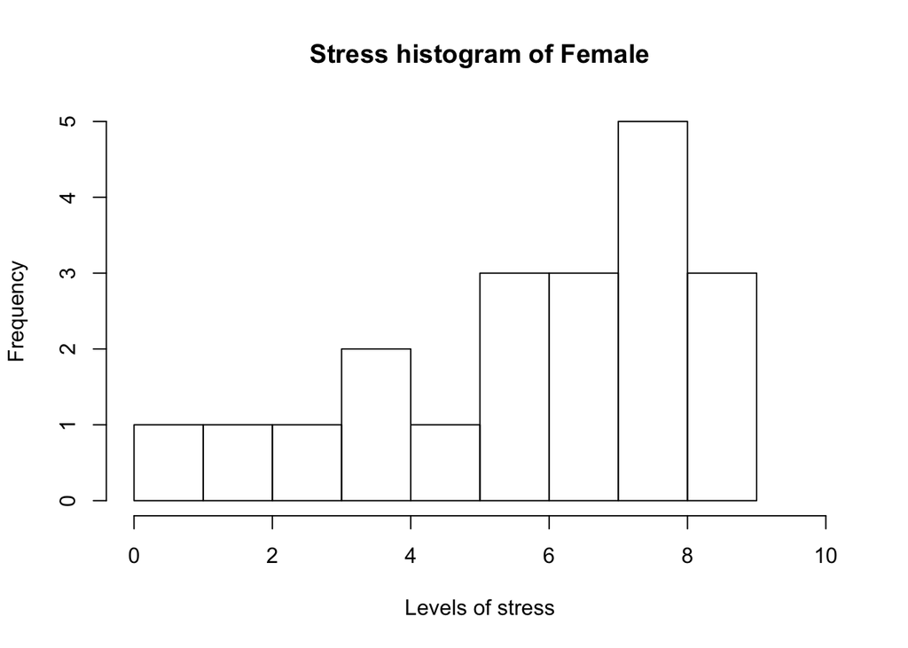

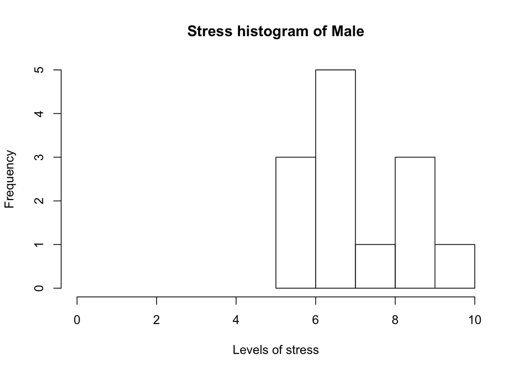

#### Boxplot

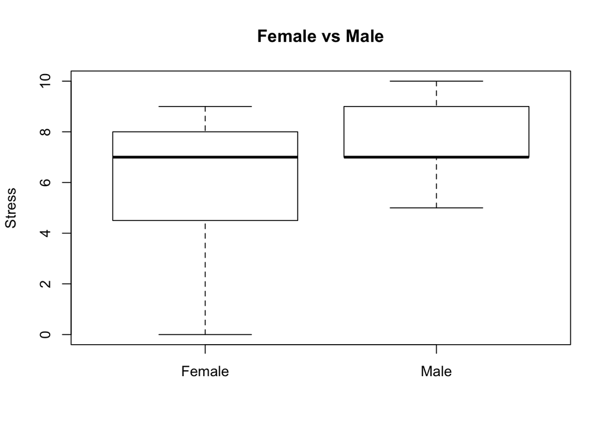

#### Shapiro.test

##### Female

```r
shapiro.test(female$stress)
```

```
##
##  Shapiro-Wilk normality test
##
## data:  female$stress
## W = 0.89744, p-value = 0.03693
```

**Anlysis**: The p-value is less than 0.05, which means the stress distribution is not a normal distribution.

##### Male

```r
shapiro.test(male$stress)
```

```
##
##  Shapiro-Wilk normality test
##
## data:  male$stress
## W = 0.92426, p-value = 0.2862
```

**Anlysis**: The p-value is greater than 0.05, which means the stress distribution can be seen as a normal distribution.

#### t-Test

```r
t.test(x=female$stress,y=male$stress)
```

```
##
##  Welch Two Sample t-test
##
## data:  female$stress and male$stress
## t = -1.6752, df = 30.973, p-value = 0.104
## alternative hypothesis: true difference in means is not equal to 0
## 95 percent confidence interval:
##  -2.6269278  0.2576971
## sample estimates:
## mean of x mean of y
##  6.200000  7.384615
```

**Anlysis**: The p-value is greater than 0.05, which means these two group are not significant different.

#### Groups - Education Level

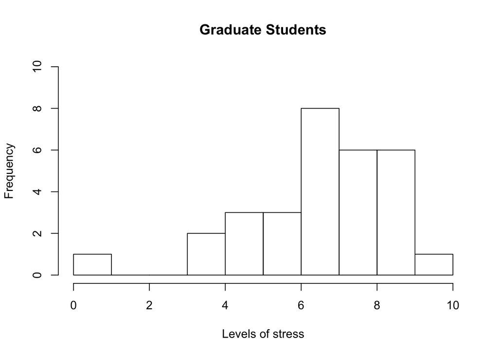

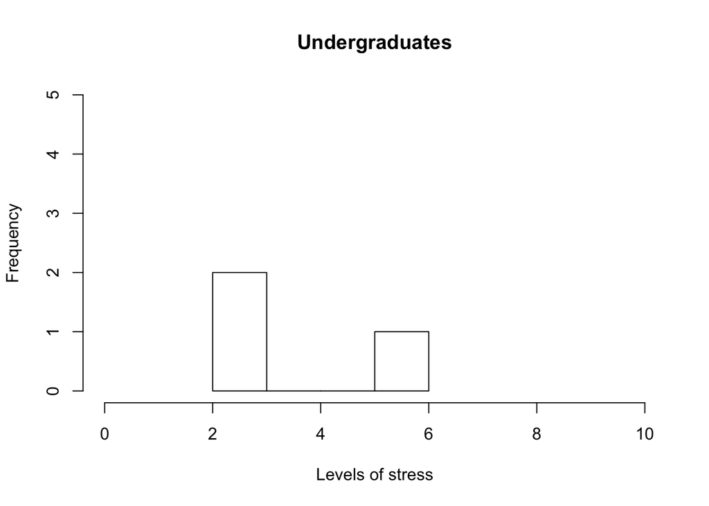

#### Boxplot

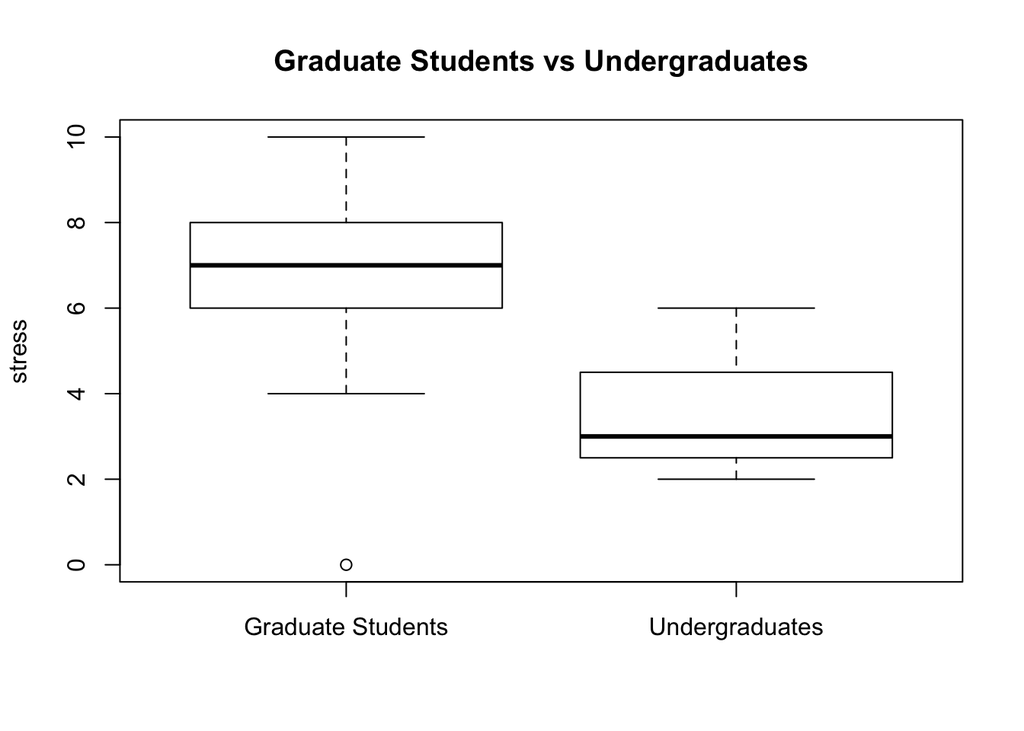

#### Shapiro.test

##### Graduate students

```r
shapiro.test(grad$stress)
```

```
##
##  Shapiro-Wilk normality test
##
## data:  grad$stress
## W = 0.88254, p-value = 0.003226
```

**Anlysis**: The p-value is less than 0.05, which means the stress distribution is not a normal distribution.

##### Undergraduates

```r
shapiro.test(undergrad$stress)
```

```
##
##  Shapiro-Wilk normality test
##
## data:  undergrad$stress
## W = 0.92308, p-value = 0.4633
```

**Anlysis**: The p-value is greater than 0.05, which means the stress distribution can be seen as a normal distribution. However, the current volume of this group is too small to do any analyses.

#### t-Test

```r
t.test(x=grad$stress,y=undergrad$stress)
```

```
##
##  Welch Two Sample t-test
##
## data:  grad$stress and undergrad$stress
## t = 2.6224, df = 2.402, p-value = 0.09928
## alternative hypothesis: true difference in means is not equal to 0
## 95 percent confidence interval:
##  -1.332235  7.932235
## sample estimates:
## mean of x mean of y
##  6.966667  3.666667
```

**Anlysis**: The p-value is greater than 0.05, which means these two group are not significant different.

#### Groups - International Students

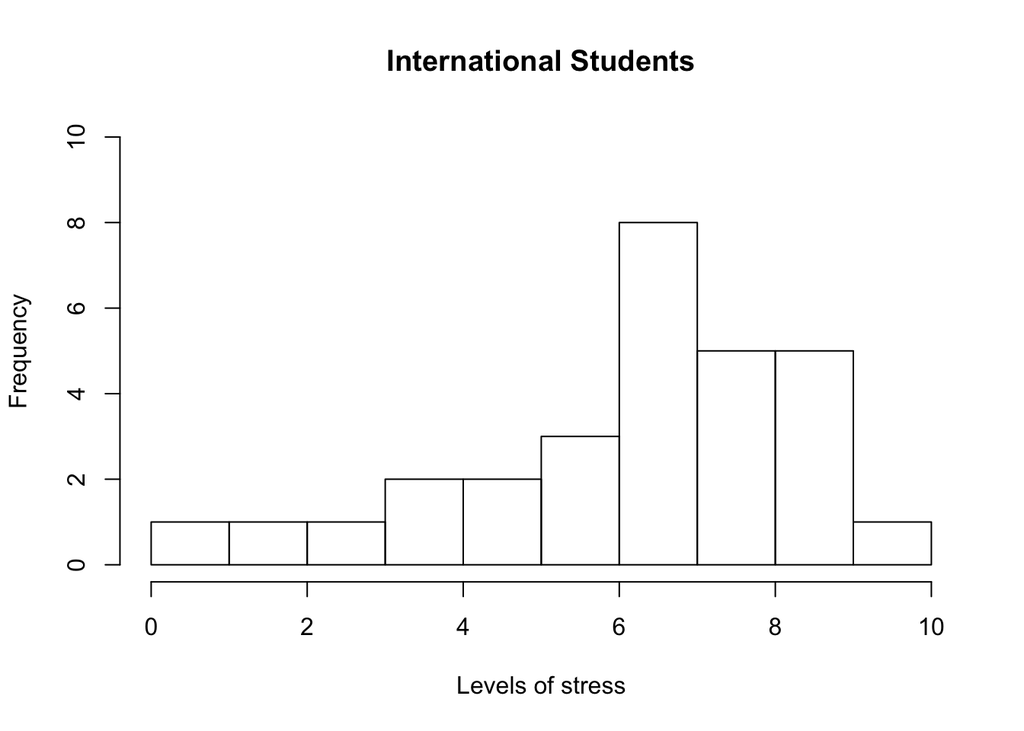

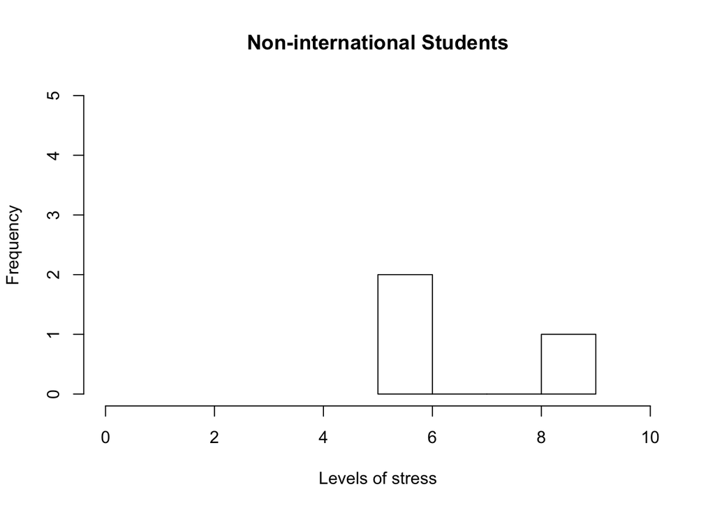

#### Boxplot

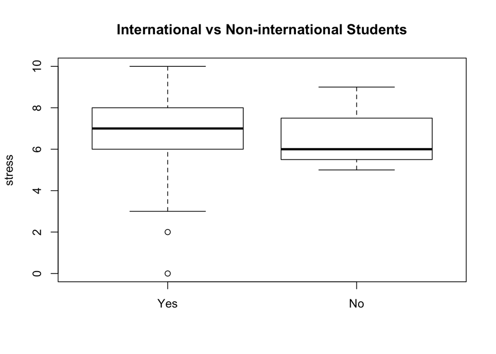

#### shapiro.test

##### International students

```r
shapiro.test(interyes$stress)
```

```
##
##  Shapiro-Wilk normality test
##
## data:  interyes$stress
## W = 0.90507, p-value = 0.01298
```

**Anlysis**: The p-value is less than 0.05, which means the stress distribution is not a normal distribution.

##### Non-international students

```r
shapiro.test(interno$stress)
```

```
##
##  Shapiro-Wilk normality test
##
## data:  interno$stress
## W = 0.92308, p-value = 0.4633
```

**Anlysis**: The p-value is greater than 0.05, which means the stress distribution can be seen as a normal distribution. However, the current volume of this group is too small to do any analyses.

#### t-Test

```r
t.test(x=interyes$stress,y=interno$stress)
```

```
##
##  Welch Two Sample t-test
##
## data:  interyes$stress and interno$stress
## t = -0.036037, df = 2.5368, p-value = 0.9739
## alternative hypothesis: true difference in means is not equal to 0
## 95 percent confidence interval:
##  -4.559570  4.467616
## sample estimates:
## mean of x mean of y
##  6.620690  6.666667
```

**Anlysis**: The p-value is greater than 0.05, which means these two group are not significant different.

#### Groups - Schools and Colleges

So far students from four colleges anwered my questionnaire. They are as follows:

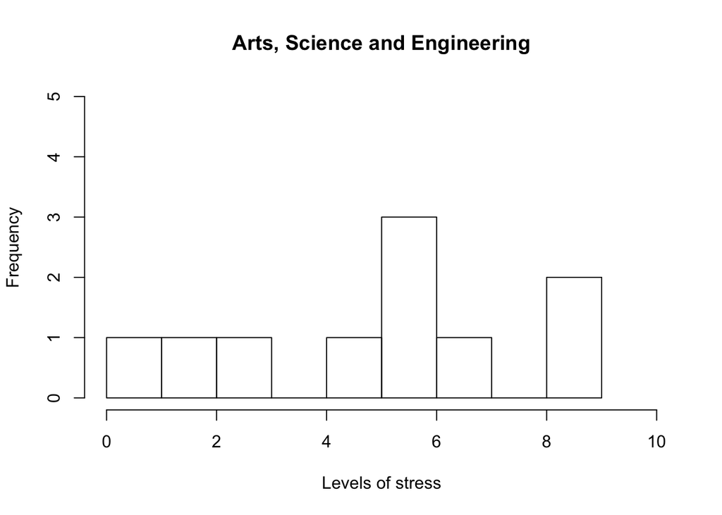

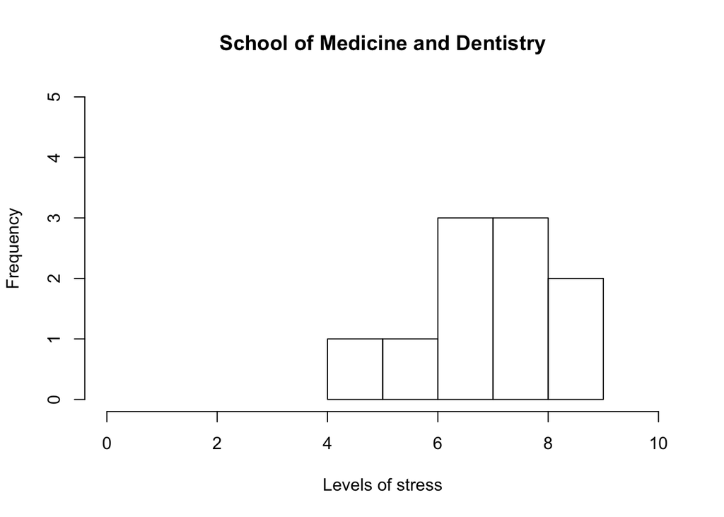

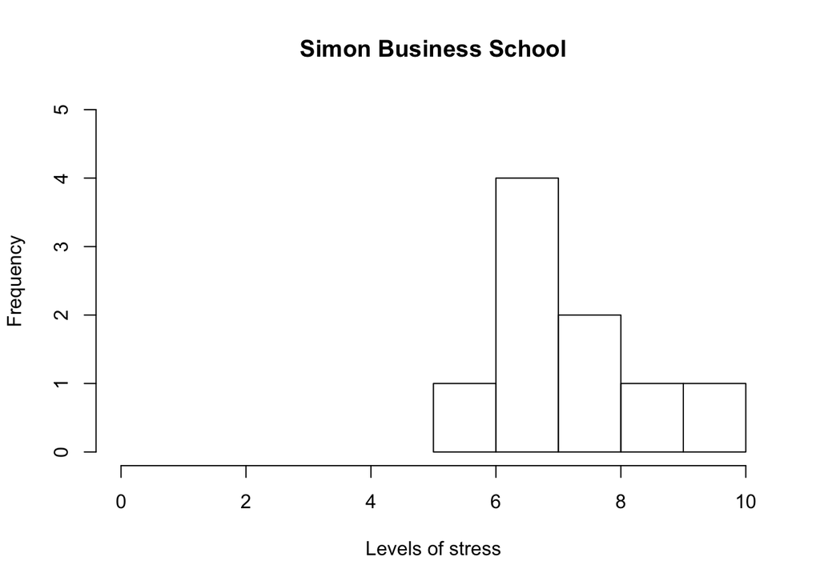

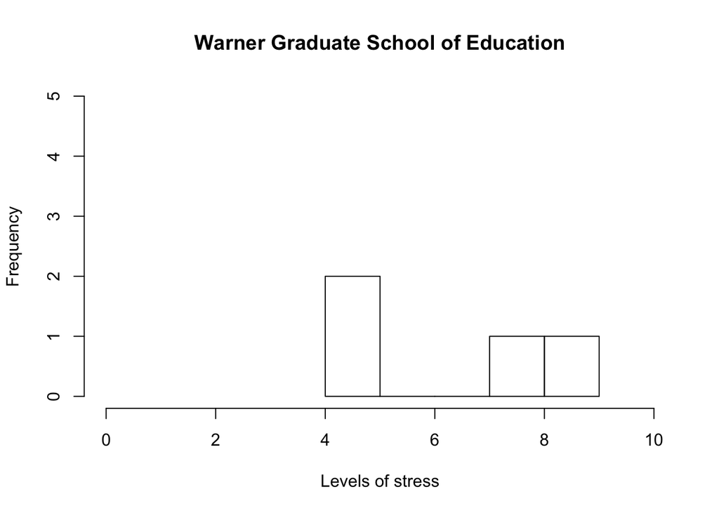

#### Boxplot

[figure not shown]

#### shapiro.test

##### Arts, Science and Engineering

```r
shapiro.test(ase$stress)
```

```
##
##  Shapiro-Wilk normality test
##
## data:  ase$stress
## W = 0.93747, p-value = 0.5253
```

**Anlysis**: The p-value is greater than 0.05, which means the stress distribution can be seen as a normal distribution.

##### School of Medicine and Dentistry

```r
shapiro.test(smd$stress)
```

```
##
##  Shapiro-Wilk normality test
##
## data:  smd$stress
## W = 0.89134, p-value = 0.1755
```

**Anlysis**: The p-value is greater than 0.05, which means the stress distribution can be seen as a normal distribution.

##### Simon Business School

```r
shapiro.test(sbs$stress)
```

```
##
##  Shapiro-Wilk normality test
##
## data:  sbs$stress
## W = 0.93048, p-value = 0.486
```

**Anlysis**: The p-value is greater than 0.05, which means the stress distribution can be seen as a normal distribution.

##### Warner Graduate School of Education

```r
shapiro.test(wgse$stress)
```

```
##
##  Shapiro-Wilk normality test
##
## data:  wgse$stress
## W = 0.91099, p-value = 0.4877
```

**Anlysis**: The p-value is greater than 0.05, which means the stress distribution can be seen as a normal distribution.

#### t-Test

##### Arts, Science and Engineering vs School of Medicine and Dentistry

```r
t.test(x=ase$stress,y=smd$stress)
```

```
##
##  Welch Two Sample t-test
##
## data:  ase$stress and smd$stress
## t = -1.9345, df = 13.444, p-value = 0.07438
## alternative hypothesis: true difference in means is not equal to 0
## 95 percent confidence interval:
##  -4.2260631  0.2260631
## sample estimates:
## mean of x mean of y
##       5.3       7.3
```

**Anlysis**: The p-value is greater than 0.05, which means these two group are not significant different.

##### Arts, Science and Engineering vs Simon Business School

```r
t.test(x=ase$stress,y=sbs$stress)
```

```
##
##  Welch Two Sample t-test
##
## data:  ase$stress and sbs$stress
## t = -2.1796, df = 13.368, p-value = 0.04772
## alternative hypothesis: true difference in means is not equal to 0
## 95 percent confidence interval:
##  -4.48492764 -0.02618347
## sample estimates:
## mean of x mean of y
##  5.300000  7.555556
```

**Anlysis**: The p-value is less than 0.05, which means these two group **are significant different**.

##### Arts, Science and Engineering vs Warner Graduate School of Education

```r
t.test(x=ase$stress,y=wgse$stress)
```

```
##
##  Welch Two Sample t-test
##
## data:  ase$stress and wgse$stress
## t = -0.79784, df = 6.8379, p-value = 0.4518
## alternative hypothesis: true difference in means is not equal to 0
## 95 percent confidence interval:
##  -4.773718  2.373718
## sample estimates:
## mean of x mean of y
##       5.3       6.5
```

**Anlysis**: The p-value is greater than 0.05, which means these two group are not significant different.

##### School of Medicine and Dentistry vs Simon Business School

```r
t.test(x=smd$stress,y=sbs$stress)
```

```
##
##  Welch Two Sample t-test
##
## data:  smd$stress and sbs$stress
## t = -0.38154, df = 16.932, p-value = 0.7076
## alternative hypothesis: true difference in means is not equal to 0
## 95 percent confidence interval:
##  -1.669158  1.158047
## sample estimates:
## mean of x mean of y
##  7.300000  7.555556
```

**Anlysis**: The p-value is greater than 0.05, which means these two group are not significant different.

##### School of Medicine and Dentistry vs Warner Graduate School of Education

```r
t.test(x=smd$stress,y=wgse$stress)
```

```
##
##  Welch Two Sample t-test
##
## data:  smd$stress and wgse$stress
## t = 0.6247, df = 3.9874, p-value = 0.5661
## alternative hypothesis: true difference in means is not equal to 0
## 95 percent confidence interval:
##  -2.760017  4.360017
## sample estimates:
## mean of x mean of y
##       7.3       6.5
```

**Anlysis**: The p-value is greater than 0.05, which means these two group are not significant different.

##### Simon Business School vs Warner Graduate School of Education

```r
t.test(x=sbs$stress,y=wgse$stress)
```

```
##
##  Welch Two Sample t-test
##
## data:  sbs$stress and wgse$stress
## t = 0.82375, df = 3.9923, p-value = 0.4564
## alternative hypothesis: true difference in means is not equal to 0
## 95 percent confidence interval:
##  -2.504891  4.616002
## sample estimates:
## mean of x mean of y
##  7.555556  6.500000
```

**Anlysis**: The p-value is greater than 0.05, which means these two group are not significant different.

-TBC-